# Relationship between field and lab resistance

Firza Riany

12/11/2020

# Description

This analysis is to find the relationship between resistance measured in the field (field resistance) and measured in the lab (lab resistance).

The raw data consists of the measurement in field from year 2000 to 2010, as well as measurement in the lab for the same period.

The spesies is Populus nigra (poplar) that was collected from several natural populations and sources in Western Europe.

Poplar is usually attacked by rust fungus that causes yellow spots on the poplar leaves. These spots reduce poplar’s effectiveness in carrying out photosynthesis processes because these spots are covering the stomata in the leaves and reducing poplar’s leaf area to catch sunrays. The impact of the massive attack caused by rust fungus is a decreased photosynthesis and growth rate which also lead to economic losses.

The idea of collecting these resistance data is to find the resistant poplar that can fight back the rust fungus.

Field resistance (Notemax) is measured in the field by scoring the infection on poplar leaves (score 1 - 6)

Lab resistance is consisted of 3 parameters: latent period (latence), number of spores on the leaves (nbsores), and spore size (taille). These parameters are measured in the lab. The poplar leaves are firstly cut into disks and they are put in the leaf disks for the lab experiment. The experiment then starts by infecting the poplar leaves with different types of rust fungus (in the data set, they are coded like 98AG69, 93JE3, etc). Then they are put in the growth chamber for 14 days.

During 14 days, we observe: 1. Latent period = the time needed by the poplar leaves to start showing the first symptom, measured daily  
2. Number of spores = number of spores found on the leaves, measured on the day 13 after infection  
3. Spore size = size of the spores, measured on the day 14 after inoculation using a scoring system (1 to 5, 1 being the smallest, 5 being the largest)

# What’s in the script

1. Raw dataset
2. Identification of missing data (data cleaning)
3. EDA and data dashboard
4. Correlation plot

# The objectives

1. Are there a completely resistant poplar in the field and in the lab?
2. What is the average resistance for poplar in the field and in the lab?
3. Is there a correlation between field resistance and lab resistance?
4. Is there a correlation between the parameters of lab resistance?

# Libraries

```r
library(readxl)  # to import the data in xlsx file
library(finalfit)  # for function ffglimpse(), extension of summary
```

```r
library(ggplot2)  # for plotting
library(plyr)  # for counting the frequency from histogram
library(ggpubr)  # to get the function ggarrange; to combine ggplots
library(cowplot)  # to draw density histogram at the sides of correlation plot
```

# The dataset

```r
pop_raw = readxl::read_xlsx("Tested_Poplar.xlsx",
                            na = "NA")  # defining the code for missing data used in the file
# Getting only the important variables
wild_yr2000 = pop_raw[,c("Classe",  # the type of population source
                         "Population",  # population of origin
                         "Clone",  # the observed poplar individuals
                         "Notemax.2010 Noveltree",  # field resistance
                         "latence.93JE3.2010",   # latent period
                         "nbsores.93JE3.2010",  # number of spores
                         "taille.93JE3.2010")]  # size of spores

colnames(wild_yr2000)[4] = "Notemax.2010"  # because the name was too long

# Check the class of each variable
str(wild_yr2000)
```

```
## tibble [93 x 7] (S3: tbl_df/tbl/data.frame)
##  $ Classe            : chr [1:93] "témoin" "témoin" "témoin" "témoin" ...
##  $ Population        : chr [1:93] "discriminant" "discriminant" "discriminant" "discriminant" ...
##  $ Clone             : chr [1:93] "ROBUSTA" "OGY" "CANDICANS" "BRABANTICA" ...
##  $ Notemax.2010      : num [1:93] 3.83 4.1 4.5 4 4.91 ...
##  $ latence.93JE3.2010: num [1:93] 8.3 NA 8.7 NA 7.65 NA NA NA NA NA ...
##  $ nbsores.93JE3.2010: num [1:93] 37.1 0 12 0 28.4 0 0 0 0 0 ...
##  $ taille.93JE3.2010 : num [1:93] 4.4 NA 5 NA 5 NA NA NA NA NA ...
```

```r
# Coercing
## Classe = chr to factor
## Population = chr to factor
## Clone = chr to factor
cols = c("Classe", "Population", "Clone")  # cols to be coerced

wild_yr2000[cols] = lapply(wild_yr2000[cols], factor)  # coerced to factor

# New data structure
str(wild_yr2000)
```

```
## tibble [93 x 7] (S3: tbl_df/tbl/data.frame)
##  $ Classe            : Factor w/ 4 levels "coll. Nationale",..: 4 4 4 4 4 4 4 4 4 4 ...
##  $ Population        : Factor w/ 33 levels "?","Assat","Baliros",..: 12 12 12 12 12 12 12 12 12 12 ...
##  $ Clone             : Factor w/ 93 levels "6-J05","6-J13",..: 77 64 41 38 89 76 11 10 36 46 ...
##  $ Notemax.2010      : num [1:93] 3.83 4.1 4.5 4 4.91 ...
##  $ latence.93JE3.2010: num [1:93] 8.3 NA 8.7 NA 7.65 NA NA NA NA NA ...
##  $ nbsores.93JE3.2010: num [1:93] 37.1 0 12 0 28.4 0 0 0 0 0 ...
##  $ taille.93JE3.2010 : num [1:93] 4.4 NA 5 NA 5 NA NA NA NA NA ...
```

# Raw distribution

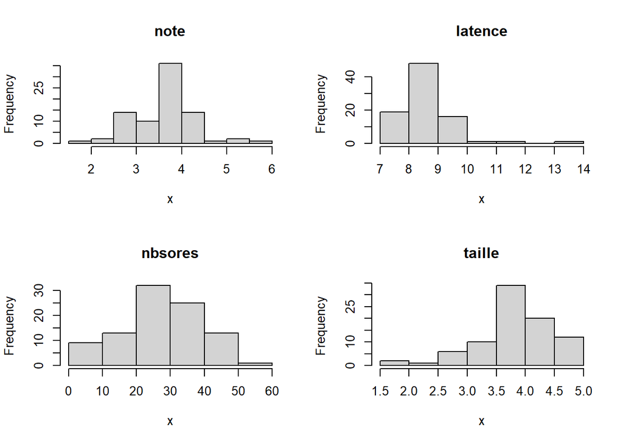

```r
par(mfrow = c(2,2))  # combine the graphs (2 columns, 2 rows)

# Create a dataframe for loop
raw_loop = data.frame("note" = wild_yr2000$Notemax.2010,
                      "latence" = wild_yr2000$latence.93JE3.2010,
                      "nbsores" = wild_yr2000$nbsores.93JE3.2010,
                      "taille" = wild_yr2000$taille.93JE3.2010)

for (i in 1:4) {  # 1:4 for the number of variables used
  x = raw_loop[,i]  # assign x for each iteration
  title = names(raw_loop[i])  # title for each iteration
  hist(x,
       main = title)  # create histogram in each iteration
}
```

Seems that there are no outliers.

Latent period is not normally distributed, which is fine, biologically speaking. It shows that there is greater amount of poplars that start showing symptoms in early time than in later time. Showing that most poplars are infected early. Meaning that they are susceptible to the pathogen in the lab.

# Data cleaning: identifying NAs

```r
# Examine NAs with ff_glimpse (package = finalfit)
explanatory = c("latence.93JE3.2010",
                "nbsores.93JE3.2010",
                "taille.93JE3.2010")

dependent = "Notemax.2010"

wild_yr2000 %>%
  finalfit::ff_glimpse(dependent, explanatory)
```

```
## $Continuous
##                                 label var_type  n missing_n missing_percent
## Notemax.2010             Notemax.2010    <dbl> 81        12            12.9
## latence.93JE3.2010 latence.93JE3.2010    <dbl> 86         7             7.5
## nbsores.93JE3.2010 nbsores.93JE3.2010    <dbl> 93         0             0.0
## taille.93JE3.2010   taille.93JE3.2010    <dbl> 85         8             8.6
##                    mean   sd min quartile_25 median quartile_75  max
## Notemax.2010        3.7  0.7 1.8         3.4    3.8         4.0  5.8
## latence.93JE3.2010  8.6  0.9 7.5         8.1    8.4         8.9 14.0
## nbsores.93JE3.2010 27.1 12.5 0.0        21.5   27.2        36.3 56.7
## taille.93JE3.2010   3.9  0.7 1.7         3.6    4.0         4.2  5.0
##
## $Categorical
## # A tibble: 93 x 0
```

1. Missing percent for Notemax = 12.9 (ratio = 12/93)
2. Missing percent for latence = 7.5 (ratio = 7/93)
3. Missing percent for nbsores = 0.0 (ratio = 0/93)
4. Missing percent for taille = 8.6 (ratio = 8/93)

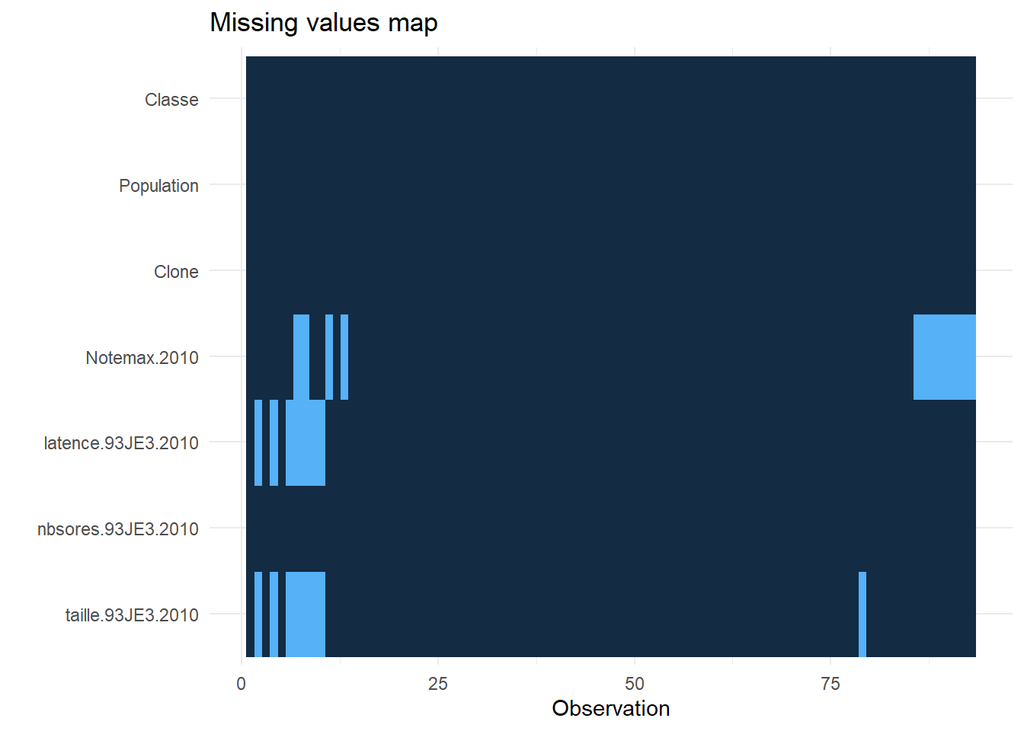

```r
# Plotting the missing data
wild_yr2000 %>%
  finalfit::missing_plot()
```

```r
# NAs in notemax, latence, and taille
# When when latence is missing, taille is most likely to be missing as well
# Check if the missing data in taille is due to missing data in latence?

# Checking the relatedness of the missing data in these two variables
# using missing_pairs
# testing H0 = missing points are MCAR (missing compeletely at random)
explanatory_1 = "latence.93JE3.2010"

dependent_1 = "taille.93JE3.2010"

wild_yr2000 %>%
  finalfit::missing_compare(dependent_1, explanatory_1) %>%
  knitr::kable(row.names = FALSE, align = c("l", "l", "r", "r", "r"))
```

| Missing data analysis: taille.93JE3.2010 |  | Not missing | Missing | p |
| --- | --- | --- | --- | --- |
| latence.93JE3.2010 | Mean (SD) | 8.6 (0.7) | 14.0 (NA) | <0.001 |

```r
# P significant, missing data in taille is due to missing data in latence
```

It means that the missing data in latence is related to the missing data in taille.

Biologically speaking, it’s how it usually is in the interaction between pathogen and the host. When latence is missing, it means that the leaves do not show symptoms during their 14 days in growth chamber (latence is non-measurable). When latence is non-measurable, it is very likely that the number of spores and spore size are non-measurable as well because the leaves do not show symptoms.

This is also an indication that the leaves are resistant to the pathogen.

And this also means that there are systemic relationship among the lab resistance.

Solutions: 1. To build a dashboard, we cannot exclude these missing data as they show the potential resistant poplars 2. But we should exclude them when we model the relationship between field and lab resistance

What about between latence and field resistance?

```r
explanatory_2 = "Notemax.2010"

dependent_2 = "latence.93JE3.2010"

wild_yr2000 %>%
  finalfit::missing_compare(dependent_2, explanatory_2) %>%
  knitr::kable(row.names = FALSE, align = c("l", "l", "r", "r", "r"))
```

| Missing data analysis: latence.93JE3.2010 |  | Not missing | Missing | p |
| --- | --- | --- | --- | --- |
| Notemax.2010 | Mean (SD) | 3.7 (0.6) | 4.6 (0.8) | 0.002 |

Therefore, these missing data should be included to build a dashboard for the share between resistant and susceptible poplars.

# Data cleaning: Excluding controls (témoin) and poplars from national collection

To inspect resistant vs susceptible poplars, we have to exclude the ‘discriminants’ or the controls (temoin).

This is because they are just the controls for the infection in other poplars. We have to clean the dataset from these controls to get a better look only on the poplars from natural population and breeding population.

We should also exclude the poplars from national collection (collection nationale) because it seems that these poplars were not tested in the field. Including these in linear regression will only create bias.

```r
rownames_remove <- c("témoin", "coll. Nationale")

wild_yr2000_clean = subset(wild_yr2000,!(Classe %in% rownames_remove))
```

# Obj 1 Data dashboard for resistant vs susceptible (in the field)

Turned out the NA is due to 1. Non-measured field resistance in the poplars from national collection.  
2. Non-active infection in certain controls.

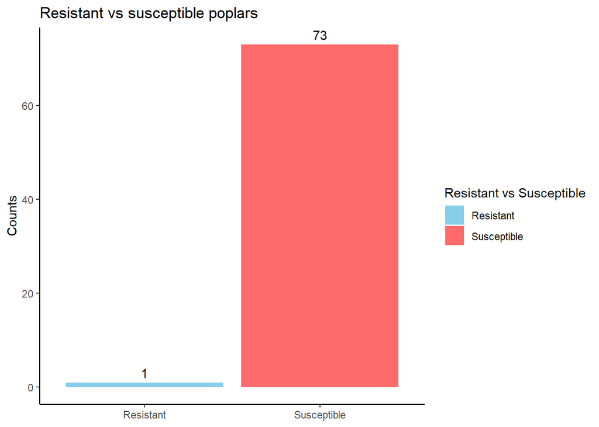

```r
# Resistant poplars in the field: Assigning -5 to NA to avoid confusion in R
wild_yr2000_clean[is.na(wild_yr2000_clean)] = -5

# Add a new variable: resistant vs susceptible
# Loop, -5 = resistant, != -5 susceptible
wild_yr2000_clean[,8] = "NA"

names(wild_yr2000_clean)[8] = "Res_vs_sus_note"

for (i in c(1:nrow(wild_yr2000_clean))) {
  if(wild_yr2000_clean$Notemax.2010[i] == -5)
    wild_yr2000_clean[i,8] = "Resistant"

  if(wild_yr2000_clean$Notemax.2010[i] != -5)
    wild_yr2000_clean[i,8] = "Susceptible"
}

# Plotting resistant vs susceptible poplars in terms of field resistance
(resist_field = ggplot(wild_yr2000_clean, aes(x = Res_vs_sus_note)) +
  geom_bar(aes(fill = Res_vs_sus_note)) +
  geom_text(stat = "count", aes(label = ..count..), vjust = -0.5) +
  labs(title = "Resistant vs susceptible poplars",
       x = "Resistant vs Susceptibe",
       y = "Counts") +
  scale_fill_manual(values = c("#87CEEB", "#FF6A6A"),
                    breaks = c("Resistant", "Susceptible"),
                    name = "Resistant vs Susceptible",
                    labels = c("Resistant", "Susceptible")) +
  theme_classic() +
  theme(axis.title.x = element_blank()))
```

```r
# Checking the population of origin of the resistant poplars
pop = plyr::count(wild_yr2000_clean$Population[
  which(wild_yr2000_clean$Notemax.2010 == -5)
])

names(pop)[1] = "Population"

clone = plyr::count(wild_yr2000_clean$Clone[
  which(wild_yr2000_clean$Notemax.2010 == -5)
])

names(clone)[1] = "Clone"

pop$Clone = paste(clone$Clone)

pop
```

```
##            Population freq     Clone
## 1 St_Genix_sur_Guiers    1 71072-501
```

It seems that there is only one poplar (71072-501) from St Genix that is resistant in the field.

Let’s see the resistant poplars in terms of lab resistance Those with latence = 14 and taille = -5

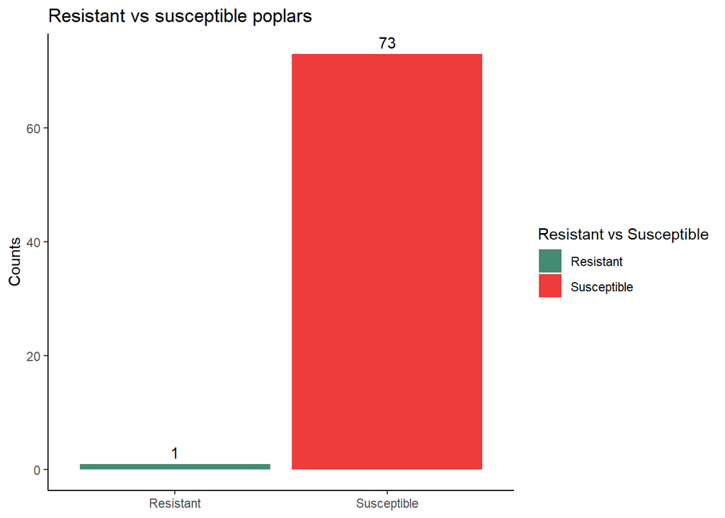

```r
# Add a new variable: resistant vs susceptible (lab)
# Loop, -5 = resistant, != -5 susceptible
wild_yr2000_clean[,9] = "NA"

names(wild_yr2000_clean)[9] = "Res_vs_sus_lab"

for (i in c(1:nrow(wild_yr2000_clean))) {
  if(wild_yr2000_clean$taille.93JE3.2010[i] == -5
     & wild_yr2000_clean$latence.93JE3.2010[i] == 14)
    wild_yr2000_clean[i,9] = "Resistant"

  if(wild_yr2000_clean$taille.93JE3.2010[i] != -5
     & wild_yr2000_clean$latence.93JE3.2010[i] != 14)
    wild_yr2000_clean[i,9] = "Susceptible"
}

# Plotting resistant vs susceptible poplars in terms of lab resistance
(resist_lab = ggplot(wild_yr2000_clean, aes(x = Res_vs_sus_lab)) +
  geom_bar(aes(fill = Res_vs_sus_lab)) +
  geom_text(stat = "count", aes(label = ..count..), vjust = -0.5) +
  labs(title = "Resistant vs susceptible poplars",
       x = "Resistant vs Susceptibe",
       y = "Counts") +
  scale_fill_manual(values = c("#458B74", "#EE3B3B"),
                    breaks = c("Resistant", "Susceptible"),
                    name = "Resistant vs Susceptible",
                    labels = c("Resistant", "Susceptible")) +
  theme_classic() +
  theme(axis.title.x = element_blank()))
```

```r
# Checking the population of origin of the resistant poplars (lab)
pop2 = plyr::count(wild_yr2000_clean$Population[
  which(wild_yr2000_clean$Res_vs_sus_lab == "Resistant")
])

names(pop2)[1] = "Population"

clone2 = plyr::count(wild_yr2000_clean$Clone[
  which(wild_yr2000_clean$Res_vs_sus_lab == "Resistant")
])

names(clone2)[1] = "Clone"

pop2$Clone = paste(clone2$Clone)

pop2
```

```
##   Population freq  Clone
## 1    Nohèdes    1 NOH-25
```

Seems that there are different poplars that are resistant in field and in the lab.

# Obj 2 Average resistance. Data dashboard for summary statistics

```r
# Field resistance (notemax)
# Removing -5 because they're outliers
wild_yr2000_new = wild_yr2000_clean[which(wild_yr2000_clean$Notemax.2010 != -5 &
                                      wild_yr2000_clean$taille.93JE3.2010 != -5), ]

summary(wild_yr2000_new)
```

```
##              Classe          Population         Clone     Notemax.2010
##  coll. Nationale: 0   Nohèdes     :13   6-J05      : 1   Min.   :1.833
##  nigrapop       :64   Ramières    :10   6-J13      : 1   1st Qu.:3.167
##  parent 14x13   : 8   ValAllier   :10   6-J15      : 1   Median :3.833
##  témoin         : 0   Gave-Mauleon: 6   71041-3-402: 1   Mean   :3.654
##                       Baudreix    : 4   71077-2-308: 1   3rd Qu.:4.000
##                       Sauveterre  : 4   92510-1    : 1   Max.   :5.400
##                       (Other)     :25   (Other)    :66
##  latence.93JE3.2010 nbsores.93JE3.2010 taille.93JE3.2010 Res_vs_sus_note
##  Min.   : 7.550     Min.   : 9.556     Min.   :1.667     Length:72
##  1st Qu.: 8.100     1st Qu.:24.275     1st Qu.:3.575     Class :character
##  Median : 8.425     Median :28.950     Median :3.800     Mode  :character
##  Mean   : 8.601     Mean   :30.168     Mean   :3.787
##  3rd Qu.: 8.912     3rd Qu.:36.825     3rd Qu.:4.200
##  Max.   :11.583     Max.   :56.700     Max.   :5.000
##
##  Res_vs_sus_lab
##  Length:72
##  Class :character
##  Mode  :character
##
##
##
##
```

```r
NM = ggplot(wild_yr2000_new, aes(x = Notemax.2010)) +
  geom_histogram(binwidth = 0.5) +
  geom_density(aes(y = 0.3 * ..count..)) +
  geom_vline(aes(xintercept = mean(Notemax.2010), color = "Mean"), size = 1) +
  geom_vline(aes(xintercept = median(Notemax.2010), color = "Median"), size = 1) +
  geom_vline(aes(xintercept = quantile(Notemax.2010, prob = 0.25), color = "Q1"),
             size = 1) +
  geom_vline(aes(xintercept = quantile(Notemax.2010, prob = 0.75), color = "Q3"),
             size = 1) +
  labs(title = "Field resistance",
       caption = "number of samples = 72, sd = 0.63",
       x = "Score",
       y = "Counts") +
  scale_color_manual(name = "Statistics", values = c(Mean = "red", Median = "orange", Q1 = "blue",
                                                     Q3 = "blue")) +
  xlim(1, 6) +
  ylim(0, 40)

# Latent period (latence)
LP = ggplot(wild_yr2000_new, aes(x = latence.93JE3.2010)) +
  geom_histogram(binwidth = 0.5) +
  geom_density(aes(y = 0.3 * ..count..)) +
  geom_vline(aes(xintercept = mean(latence.93JE3.2010), color = "Mean"), size = 1) +
  geom_vline(aes(xintercept = median(latence.93JE3.2010), color = "Median"), size = 1) +
  geom_vline(aes(xintercept = quantile(latence.93JE3.2010, prob = 0.25), color = "Q1"),
             size = 1) +
  geom_vline(aes(xintercept = quantile(latence.93JE3.2010, prob = 0.75), color = "Q3"),
             size = 1) +
  labs(title = "Latent period",
       caption = "sd = 0.69",
       x = "Days",
       y = "Counts") +
  scale_color_manual(name = "Statistics", values = c(Mean = "red", Median = "orange", Q1 = "blue",
                                                     Q3 = "blue")) +
  xlim(7, 12) +
  ylim(0, 40)

# sd(wild_yr2000_new$latence.93JE3.2010)

# Number of spores
NS = ggplot(wild_yr2000_new, aes(x = nbsores.93JE3.2010)) +
  geom_histogram(binwidth = 1.0) +
  geom_density(aes(y = 0.3 * ..count..)) +
  geom_vline(aes(xintercept = mean(nbsores.93JE3.2010), color = "Mean"), size = 1) +
  geom_vline(aes(xintercept = median(nbsores.93JE3.2010), color = "Median"), size = 1) +
  geom_vline(aes(xintercept = quantile(nbsores.93JE3.2010, prob = 0.25), color = "Q1"),
             size = 1) +
  geom_vline(aes(xintercept = quantile(nbsores.93JE3.2010, prob = 0.75), color = "Q3"),
             size = 1) +
  labs(title = "Number of spores",
       caption = "sd = 9.49",
       x = "Number (counts)",
       y = "Counts") +
  scale_color_manual(name = "Statistics", values = c(Mean = "red", Median = "orange", Q1 = "blue",
                                                     Q3 = "blue")) +
  xlim(0, 60) +
  ylim(0, 40)

# sd(wild_yr2000_new$nbsores.93JE3.2010)

# Spore size
SS = ggplot(wild_yr2000_new, aes(x = taille.93JE3.2010)) +
  geom_histogram(binwidth = 0.5) +
  geom_density(aes(y = 0.3 * ..count..)) +
  geom_vline(aes(xintercept = mean(taille.93JE3.2010), color = "Mean"), size = 1) +
  geom_vline(aes(xintercept = median(taille.93JE3.2010), color = "Median"), size = 1) +
  geom_vline(aes(xintercept = quantile(taille.93JE3.2010, prob = 0.25), color = "Q1"),
             size = 1) +
  geom_vline(aes(xintercept = quantile(taille.93JE3.2010, prob = 0.75), color = "Q3"),
             size = 1) +
  labs(title = "Spore size",
       caption = "sd = 0.68",
       x = "Score",
       y = "Counts") +
  scale_color_manual(name = "Statistics", values = c(Mean = "red", Median = "orange", Q1 = "blue",
                                                     Q3 = "blue")) +
  xlim(1, 5) +
  ylim(0, 40)

# sd(wild_yr2000_new$taille.93JE3.2010)
quantile(wild_yr2000_new$nbsores.93JE3.2010, prob = 0.75)
```

```
##    75%
## 36.825
```

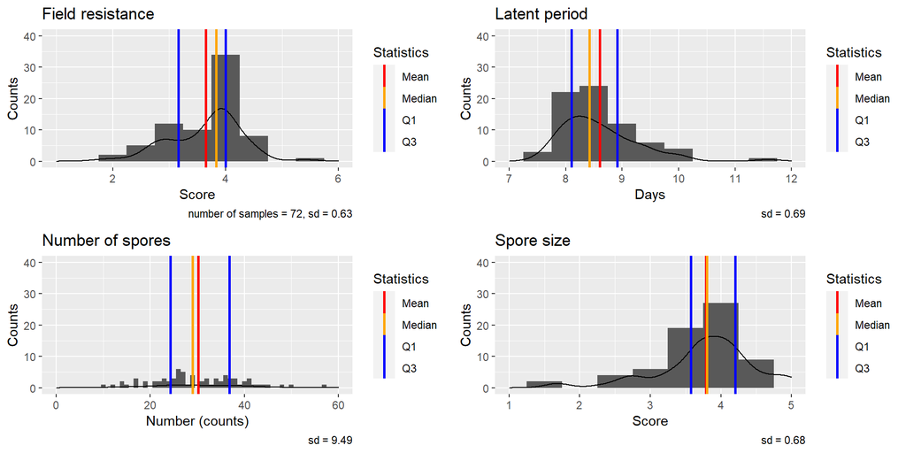

```r
# Combining the plots
dist = ggpubr::ggarrange(NM, LP, NS, SS)

dist
```

- Field resistance  
  Seems that the poplars are in intermediate resistance, on average. For a note, field resistance is measured using scoring system from 1 - 6; score 1 means that infection covers only a small area of leaves, score 6 means that infection covers almost all area of poplar leaves. In other words, when field resistance score is 1 then the poplar is resistant, when field resistance score is 6 then the poplar is susceptible.

# Obj 3 Correlation between field resistance and lab resistance

To observe the relationships between the parameters of resistance. Furthermore, to see if field resistance can be explained by the parameters of lab resistance or not.

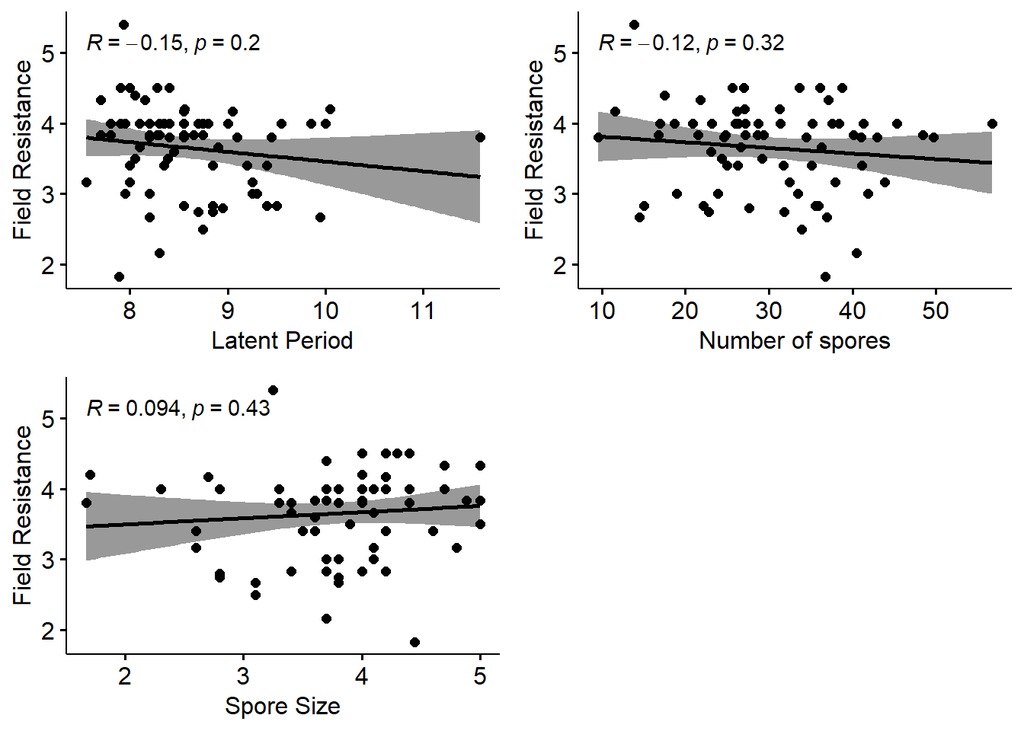

```r
LP_NM = ggpubr::ggscatter(wild_yr2000_new,
                          x = "latence.93JE3.2010", y = "Notemax.2010",
                          add = "reg.line", conf.int = TRUE,
                          cor.coef = TRUE, cor.method = "pearson",
                          xlab = "Latent Period", ylab = "Field Resistance")

NS_NM = ggpubr::ggscatter(wild_yr2000_new,
                          x = "nbsores.93JE3.2010", y = "Notemax.2010",
                          add = "reg.line", conf.int = TRUE,
                          cor.coef = TRUE, cor.method = "pearson",
                          xlab = "Number of spores", ylab = "Field Resistance")

SS_NM = ggpubr::ggscatter(wild_yr2000_new,
                          x = "taille.93JE3.2010", y = "Notemax.2010",
                          add = "reg.line", conf.int = TRUE,
                          cor.coef = TRUE, cor.method = "pearson",
                          xlab = "Spore Size", ylab = "Field Resistance")

corr = ggpubr::ggarrange(LP_NM, NS_NM, SS_NM)
corr
```

It seems that there are no clear correlation between field and lab resistance. It seems unclear whether lab resistance can explain or predict field resistance.

# Obj 4 Correlation between parameters of lab resistance

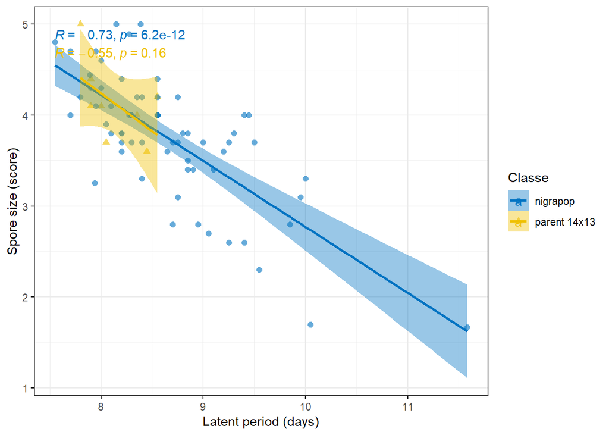

```r
# Designing the main correlation plot latence x taille
(main_cor = ggpubr::ggscatter(wild_yr2000_new,
                              x = "latence.93JE3.2010", y = "taille.93JE3.2010",
                              add = "reg.line", conf.int = TRUE,
                              color = "Classe", palette = "jco",
                              shape = "Classe", size = 2,
                              alpha = 0.6, ggtheme = theme_bw(),
                              xlab = "Latent period (days)",
                              ylab = "Spore size (score)") +
  stat_cor(aes(color = Classe)))  # correlation line
```

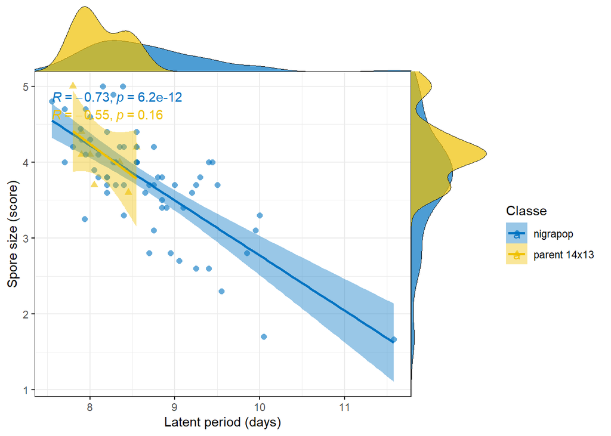

```r
# Because I differentiated correlation for parent and nigrapop, I want to provide
# the density histogram for poplars from parent and nigrapop

# Density histogram for latent period, plotted at x axis
xdens = axis_canvas(main_cor, axis = "x") +  # create the canvas base
  geom_density(data = wild_yr2000_new,
               aes(x = latence.93JE3.2010, fill = Classe),
               alpha = 0.7, size = 0.2) +  # density histogram for latence
  ggpubr::fill_palette("jco")  # color palette for fill
# Density histogram for taille, plotted at y axis
ydens = axis_canvas(main_cor, axis = "y", coord_flip = TRUE) +
  geom_density(data = wild_yr2000_new,
               aes(x = taille.93JE3.2010, fill = Classe),
               alpha = 0.7, size = 0.2) +  # density histogram for taille
  coord_flip() +  # flipping the coordinate, 90 degrees
  ggpubr::fill_palette("jco")
# Adding xdens on the x axis of correlation plot
main_cor1 = cowplot::insert_xaxis_grob(main_cor, xdens,
                                       grid::unit(0.2, "null"),
                                       position = "top")
# Adding ydens on the y axis of correlation plot
main_cor2 = cowplot::insert_yaxis_grob(main_cor1, ydens,
                                       grid::unit(0.2, "null"),
                                       position = "right")

cowplot::ggdraw(main_cor2)
```

```r
# Saving the plot
ggsave("correlation_plot.png",
       device = "png",
       width = 15,
       height = 10,
       units = "cm",
       dpi = 300)
```

It seems that there is a clear correlation between the parameters of lab resistance (latent period and spore size)